# Multi Output Regression Models in sklearn

### Next steps

- Learn about K-fold [cross-validation](https://scikit-learn.org/stable/modules/cross_validation.html).
- Hyper parameters of the ML models are set to default. In sklearn hyper parameters can be fine tuned using [Grid Search](https://scikit-learn.org/stable/modules/generated/sklearn.model_selection.GridSearchCV.html#sklearn.model_selection.GridSearchCV), Random Search, Bayesian Optimization, and Genetic Algorithms.
- Explore evaluation metrics for regression models like MSE, RMSE, MAE, MPE, R2, etc.
- There are many other machine learning models available in [sklearn](https://scikit-learn.org/stable/index.html) such as [SGD](https://scikit-learn.org/stable/modules/generated/sklearn.linear_model.SGDRegressor.html#sklearn.linear_model.SGDRegressor), [Polynomial Regession](https://scikit-learn.org/stable/modules/linear_model.html#polynomial-regression-extending-linear-models-with-basis-functions), [Multi Output Regressor](https://scikit-learn.org/stable/modules/generated/sklearn.multioutput.MultiOutputRegressor.html#sklearn.multioutput.MultiOutputRegressor), [Regressor Chain](https://scikit-learn.org/stable/modules/generated/sklearn.multioutput.RegressorChain.html#sklearn.multioutput.RegressorChain), and many more.
- Supervised Learning methods in python is not limited to sklearn library, other popular libraries are SkLearn-rvm, PyCaret, and XgBoost.
- Regression model can also trained using Artifical Neural Networks (ANN) using libraries such as PyTorch, Keras, Caffe, and Tensorflow.

```python
# Importing essential python libraries
import sklearn
from sklearn.metrics import mean_squared_error
print("sklearn version:",sklearn.__version__)
```

```
sklearn version: 0.22.1
```

```python
# Generate randam dataset with three inputs and three outputs.
from sklearn.datasets import make_regression
X, y = make_regression(n_samples = 1000, n_features = 3, n_informative = 5, n_targets = 3,
                                   random_state = 101, noise = 0.5)
print('shape of input: {} shape of output: {}'.format(X.shape, y.shape))
```

```
shape of input: (1000, 3) shape of output: (1000, 3)
```

```python
# Splitting the dataset into 70% training and 30% test set.
from sklearn.model_selection import train_test_split
X_train, X_test, y_train, y_test = train_test_split(X, y, test_size=0.30, random_state=42)
print("X_train:{} X_test:{} y_train:{} y_test:{}".format(X_train.shape, X_test.shape, y_train.shape, y_test.shape))
```

```
X_train:(700, 3) X_test:(300, 3) y_train:(700, 3) y_test:(300, 3)
```

### ML models

[Least Squares Linear Regression](https://scikit-learn.org/stable/modules/linear_model.html#ordinary-least-squares)  
[K-Nearest Neighbors](https://scikit-learn.org/stable/modules/generated/sklearn.neighbors.KNeighborsRegressor.html#sklearn.neighbors.KNeighborsRegressor)  
[Decision Tree Regressor](https://scikit-learn.org/stable/modules/generated/sklearn.tree.DecisionTreeRegressor.html#sklearn.tree.DecisionTreeRegressor)  
Random Forest Regressor  
[Support Vector Machines](https://scikit-learn.org/stable/modules/generated/sklearn.svm.SVR.html#sklearn.svm.SVR)  
[Multi-layer Perceptron](https://scikit-learn.org/stable/modules/generated/sklearn.neural_network.MLPRegressor.html#sklearn.neural_network.MLPRegressor)

```python
# Linear Regression model
from sklearn.linear_model import LinearRegression
acc, mse = list(), list()
LR = LinearRegression().fit(X_train, y_train)
y_pred = LR.predict(X_test)
acc.append(LR.score(X_test, y_test))
mse.append(mean_squared_error(y_test, y_pred))
```

[output not shown]

```python
# K-Nearest Neighbors
from sklearn.neighbors import KNeighborsRegressor
KNN = KNeighborsRegressor().fit(X_train, y_train)
y_pred = KNN.predict(X_test)
acc.append(KNN.score(X_test, y_test))
mse.append(mean_squared_error(y_test, y_pred))
# print(KNN.kneighbors())
```

[output not shown]

```python
# Decision Tree
from sklearn.tree import DecisionTreeRegressor
DT = DecisionTreeRegressor().fit(X_train, y_train)
y_pred = DT.predict(X_test)
acc.append(DT.score(X_test, y_test))
mse.append(mean_squared_error(y_test, y_pred))
```

[output not shown]

```python
# Random Forest
from sklearn.ensemble import RandomForestRegressor
RF = RandomForestRegressor().fit(X_train, y_train)
y_pred = RF.predict(X_test)
acc.append(RF.score(X_test, y_test))
mse.append(mean_squared_error(y_test, y_pred))
```

[output not shown]

```python
# Support Vector Machine
from sklearn.svm import LinearSVR
from sklearn.multioutput import MultiOutputRegressor
SVR = LinearSVR()
Mu_SVR = MultiOutputRegressor(SVR)
Mu_SVR.fit(X_train, y_train)
y_pred = Mu_SVR.predict(X_test)
acc.append(Mu_SVR.score(X_test, y_test))
mse.append(mean_squared_error(y_test, y_pred))
```

```python
# Multi-layer Perceptron
from sklearn.neural_network import MLPRegressor
MLP = MLPRegressor(random_state=1, max_iter=500).fit(X_train, y_train)
y_pred = MLP.predict(X_test)
acc.append(MLP.score(X_test, y_test))
mse.append(mean_squared_error(y_test, y_pred))
```

[output not shown]

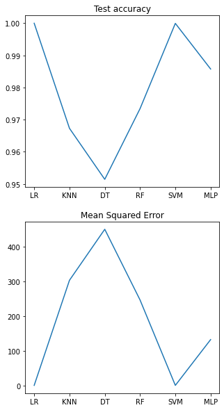

```python
import matplotlib.pyplot as plt
xlab = ["LR", "KNN", "DT", "RF", "SVM", "MLP"]
plt.figure(figsize=(5,10))
plt.subplot(2,1,1)
plt.title("Test accuracy")
plt.plot(xlab,acc)
plt.subplot(2,1,2)
plt.title("Mean Squared Error")
plt.plot(xlab,mse)
```

```python
# lets consider LR model as it has better performances
X = [0.0, 0.0, 0.0] # X1, X2, X3
print("Y:",LR.predict([X])) # Y1, Y2, Y3
```

```
Y: [[ 0.04021606 -0.03343436  0.0383187 ]]
```

```python
# Optimisation
# I havn't found any relavent references to optimised Y values based on X values.
# Linear Regreesion equation parameters
print(LR.coef_, LR.intercept_)
```

```
[[83.83430665 17.65346858 96.1039743 ]
 [80.72696737 15.23719827 17.68445124]
 [27.51565193  5.85102339 20.44691219]] [ 0.04021606 -0.03343436  0.0383187 ]
```

### *References*

[1] [Machine Learning Mastery - How to Develop Multi-Output Regression Models with Python](https://machinelearningmastery.com/multi-output-regression-models-with-python/)  
[2] [Tools for Sharing Jupyter Notebooks Online](https://towardsdatascience.com/tools-for-sharing-jupyter-notebooks-online-28c8d4ff821c#:~:text=Jupyter%20nbviewer%20is%20a%20tool,you%20can%20share%20with%20others.)